# Minor miRNA Prevalence Analysis

Characterizing the Frequency Distribution of Low-Abundance miRNAs in hMSC EVs

DartCF Bioinformatics Core

2026-01-02

# Overview

**Key questions addressed:**

1. How many minor miRNAs are detected, and what is their collective contribution?
2. What is the prevalence distribution? (i.e., in how many samples is each miRNA detected?)
3. Which minor miRNAs are “ubiquitous” (present in all/most samples) vs “sporadic”?
4. How does abundance relate to prevalence among minor miRNAs?

# 1. Load Required Libraries

```r
library(here)
library(readxl)
library(readr)
library(dplyr)
library(tidyr)
library(ggplot2)
library(RColorBrewer)
library(scales)
library(ggrepel)    # For label repelling on volcano plot
library(officer)    # For Word document generation
library(flextable)  # For formatted tables in Word

# Set theme for all plots
theme_set(theme_bw(base_size = 16))

# Create output directory
output_dir <- params$output_dir
dir.create(output_dir, recursive = TRUE, showWarnings = FALSE)

# Helper function to save figures in both PNG and PDF formats
save_figure <- function(plot, filename, width = 10, height = 8) {
  ggsave(file.path(output_dir, paste0(filename, ".png")), plot,
         width = width, height = height, dpi = 300)
  ggsave(file.path(output_dir, paste0(filename, ".pdf")), plot,
         width = width, height = height)
  cat("Saved:", filename, ".png/.pdf\n")
}
```

# 2. Load and Prepare Data

```r
# Define input file paths
raw_data_file <- here("data", "raw",
                      "GSE282919_VLP00436_miRNA_P33_21NOV2019_QC_and_Processed_Data.xlsx")
metadata_file <- here("data", "metadata", "sample_metadata.csv")

# Load sample metadata (curated file with treatment group assignments)
sample_metadata <- read_csv(metadata_file, show_col_types = FALSE)

# Create sample mapping for compatibility with original code
sample_mapping <- sample_metadata %>%
  dplyr::select(Sample, Treatment_Group) %>%
  as.data.frame()
rownames(sample_mapping) <- sample_mapping$Sample
names(sample_mapping)[names(sample_mapping) == "Treatment_Group"] <- "comparison_7"

# Define sample groups for analysis
analysis_groups <- c("CF_Asp_Neg", "HC", "UNSTIM")
samples_to_analyze <- sample_metadata %>%
  filter(Treatment_Group %in% analysis_groups, In_Current_Study == TRUE) %>%
  pull(Sample)

cat("Total samples for analysis:", length(samples_to_analyze), "\n")
```

```
## Total samples for analysis: 46
```

```r
cat("Groups included:", paste(analysis_groups, collapse = ", "), "\n")
```

```
## Groups included: CF_Asp_Neg, HC, UNSTIM
```

# 3. Calculate Fractional Abundances and Define Minor miRNAs

Minor miRNAs are defined as those with <1% mean fractional abundance **in CF BAL-exposed samples specifically**. This focuses the analysis on miRNAs that are “minor” in the therapeutic context of interest.

```r
# Load preprocessed count data (already has correct sample mapping and QC filtering)
count_data <- read_csv(here("data", "processed", "mirna_counts_filtered.csv"),
                        show_col_types = FALSE)

# Convert to matrix format
raw_counts <- as.data.frame(count_data[, -1])  # Remove Gene_ID column
rownames(raw_counts) <- count_data$Gene_ID

# Subset to analysis samples
raw_counts <- raw_counts[, samples_to_analyze]

cat("Loaded preprocessed data:", nrow(raw_counts), "miRNAs ×", ncol(raw_counts), "samples\n")
```

```
## Loaded preprocessed data: 2083 miRNAs × 46 samples
```

```r
# Calculate total reads per sample
sample_totals <- colSums(raw_counts, na.rm = TRUE)

# Calculate fractional abundance (each sample sums to 1)
frac_abundance <- sweep(raw_counts, 2, sample_totals, FUN = "/")


# Identify CF BAL samples for defining minor miRNAs
cf_samples <- sample_mapping$Sample[sample_mapping$comparison_7 == "CF_Asp_Neg"]
cf_samples <- intersect(cf_samples, samples_to_analyze)

# Calculate mean fractional abundance in CF samples specifically
cf_frac_abundance <- frac_abundance[, cf_samples]
cf_mean_frac <- rowMeans(cf_frac_abundance)

# Also calculate overall mean for reference
mean_frac_abundance <- rowMeans(frac_abundance)

# Define threshold (1% = 0.01 fractional abundance)
threshold_fraction <- 0.01

# Identify major vs minor miRNAs BASED ON CF SAMPLES
major_mirna_names <- names(cf_mean_frac[cf_mean_frac >= threshold_fraction])
minor_mirna_names <- names(cf_mean_frac[cf_mean_frac < threshold_fraction])

# Extract minor miRNA data (all samples, but defined by CF abundance)
minor_frac_abundance <- frac_abundance[minor_mirna_names, ]
minor_mean_frac <- mean_frac_abundance[minor_mirna_names]  # Overall mean for display
minor_cf_mean_frac <- cf_mean_frac[minor_mirna_names]      # CF-specific mean

cat("\n=== miRNA Classification Summary ===\n")
```

```
##
## === miRNA Classification Summary ===
```

```r
cat("(Minor defined as <1% mean abundance in CF BAL samples)\n\n")
```

```
## (Minor defined as <1% mean abundance in CF BAL samples)
```

```r
cat("Total miRNAs detected:", nrow(frac_abundance), "\n")
```

```
## Total miRNAs detected: 2083
```

```r
cat("CF BAL samples used for classification:", length(cf_samples), "\n")
```

```
## CF BAL samples used for classification: 16
```

```r
cat("Major miRNAs (≥1% in CF):", length(major_mirna_names), "\n")
```

```
## Major miRNAs (≥1% in CF): 12
```

```r
cat("Minor miRNAs (<1% in CF):", length(minor_mirna_names), "\n")
```

```
## Minor miRNAs (<1% in CF): 2071
```

```r
cat("\nCollective contribution of minor miRNAs (overall mean):",
    sprintf("%.2f%%", sum(minor_mean_frac) * 100), "\n")
```

```
##
## Collective contribution of minor miRNAs (overall mean): 30.85%
```

# 4. Calculate Prevalence Metrics

Prevalence is defined as the proportion of samples in which a miRNA is detected (count > 0). This distinguishes “ubiquitous” minor miRNAs (present everywhere at low levels) from “sporadic” ones (present in only some samples).

```r
# Define detection threshold (any non-zero count)
# Using raw counts for detection, as fractional abundance can introduce artifacts
minor_raw_counts <- raw_counts[minor_mirna_names, ]

# Calculate prevalence: proportion of samples where miRNA is detected
n_samples <- ncol(minor_raw_counts)
minor_prevalence <- rowSums(minor_raw_counts > 0) / n_samples

# Create summary data frame for minor miRNAs
minor_summary <- data.frame(
  miRNA = minor_mirna_names,
  Mean_Fraction = minor_mean_frac,
  Mean_Percentage = minor_mean_frac * 100,
  CF_Mean_Fraction = minor_cf_mean_frac,
  CF_Mean_Percentage = minor_cf_mean_frac * 100,
  Prevalence = minor_prevalence,
  N_Samples_Detected = rowSums(minor_raw_counts > 0),
  Total_Samples = n_samples,
  stringsAsFactors = FALSE
) %>%
  arrange(desc(Mean_Fraction))

# Add prevalence categories
minor_summary <- minor_summary %>%
  mutate(
    Prevalence_Category = case_when(
      Prevalence == 1.0 ~ "Ubiquitous (100%)",
      Prevalence >= 0.75 ~ "High (75-99%)",
      Prevalence >= 0.50 ~ "Moderate (50-74%)",
      Prevalence >= 0.25 ~ "Low (25-49%)",
      TRUE ~ "Rare (<25%)"
    ),
    Prevalence_Category = factor(Prevalence_Category,
                                  levels = c("Ubiquitous (100%)", "High (75-99%)",
                                            "Moderate (50-74%)", "Low (25-49%)", "Rare (<25%)"))
  )

cat("\n=== Prevalence Distribution Summary ===\n")
```

```
##
## === Prevalence Distribution Summary ===
```

```r
cat("(Overall prevalence: detection across all", n_samples, "samples)\n\n")
```

```
## (Overall prevalence: detection across all 46 samples)
```

```r
print(table(minor_summary$Prevalence_Category))
```

```
##
## Ubiquitous (100%)     High (75-99%) Moderate (50-74%)
##              1014               659               394
##      Low (25-49%)       Rare (<25%)
##                 3                 1
```

# 5. Visualizations of Minor miRNA Prevalence

## 5.1 Histogram: Number of Samples Detected

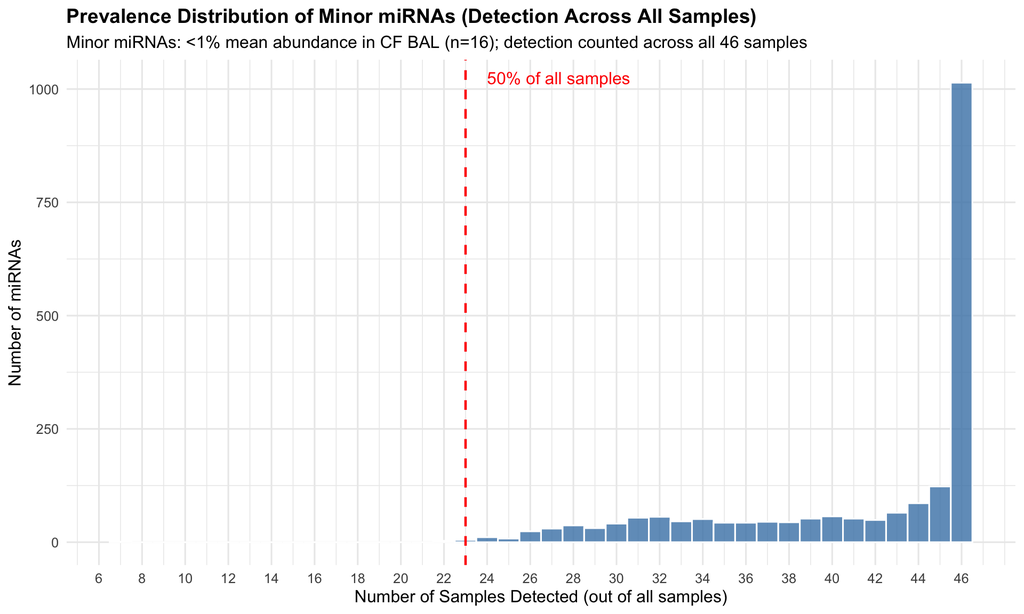

```r
# Histogram showing distribution of sample detection counts
p1 <- ggplot(minor_summary, aes(x = N_Samples_Detected)) +
  geom_histogram(binwidth = 1, fill = "steelblue", color = "white", alpha = 0.8) +
  geom_vline(xintercept = n_samples * 0.5, linetype = "dashed", color = "red", size = 0.8) +
  annotate("text", x = n_samples * 0.5 + 1, y = Inf,
           label = "50% of all samples", color = "red", vjust = 2, hjust = 0) +
  labs(
    title = "Prevalence Distribution of Minor miRNAs (Detection Across All Samples)",
    subtitle = sprintf("Minor miRNAs: <1%% mean abundance in CF BAL (n=%d); detection counted across all %d samples",
                      length(cf_samples), n_samples),
    x = "Number of Samples Detected (out of all samples)",
    y = "Number of miRNAs"
  ) +
  scale_x_continuous(breaks = seq(0, n_samples, by = 2)) +
  theme_minimal(base_size = 12) +
  theme(plot.title = element_text(face = "bold", size = 14))

print(p1)
```

```r
save_figure(p1, "minor_miRNA_prevalence_histogram", width = 10, height = 6)
```

```
## Saved: minor_miRNA_prevalence_histogram .png/.pdf
```

## 5.2 Stacked Bar Plot: Prevalence Categories by Treatment Group

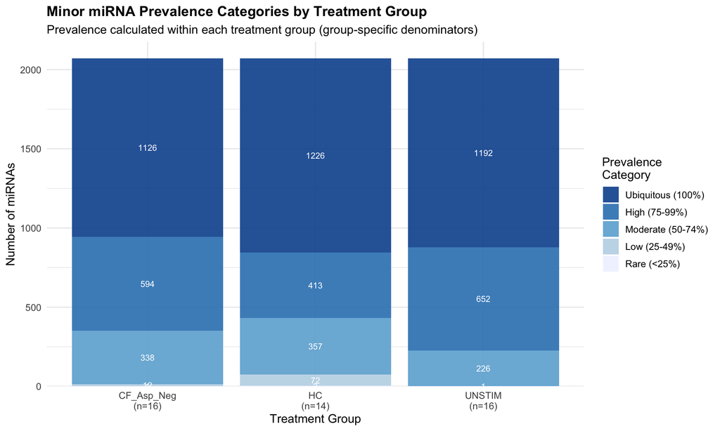

```r
# Calculate prevalence within each treatment group and assign categories
treatment_groups <- c("CF_Asp_Neg", "HC", "UNSTIM")

# Get sample counts per group for labeling
group_sample_counts <- sapply(treatment_groups, function(grp) {
  grp_samples <- sample_mapping$Sample[sample_mapping$comparison_7 == grp]
  length(intersect(grp_samples, samples_to_analyze))
})

group_prevalence_categories <- lapply(treatment_groups, function(grp) {
  grp_samples <- sample_mapping$Sample[sample_mapping$comparison_7 == grp]
  grp_samples <- intersect(grp_samples, samples_to_analyze)

  grp_counts <- minor_raw_counts[, grp_samples, drop = FALSE]
  n_grp <- ncol(grp_counts)

  # Calculate prevalence within this group
  grp_prevalence <- rowSums(grp_counts > 0) / n_grp

  # Assign prevalence categories
  prev_cat <- case_when(
    grp_prevalence == 1.0 ~ "Ubiquitous (100%)",
    grp_prevalence >= 0.75 ~ "High (75-99%)",
    grp_prevalence >= 0.50 ~ "Moderate (50-74%)",
    grp_prevalence >= 0.25 ~ "Low (25-49%)",
    TRUE ~ "Rare (<25%)"
  )

  data.frame(
    miRNA = rownames(grp_counts),
    Treatment = grp,
    Prevalence = grp_prevalence,
    Prevalence_Category = factor(prev_cat,
                                  levels = c("Ubiquitous (100%)", "High (75-99%)",
                                            "Moderate (50-74%)", "Low (25-49%)", "Rare (<25%)")),
    stringsAsFactors = FALSE
  )
})

group_prev_cat_df <- bind_rows(group_prevalence_categories)

# Summarize counts by treatment and category
category_by_group <- group_prev_cat_df %>%
  group_by(Treatment, Prevalence_Category) %>%
  summarise(N_miRNAs = n(), .groups = 'drop') %>%
  complete(Treatment, Prevalence_Category, fill = list(N_miRNAs = 0))

# Set treatment factor order
category_by_group$Treatment <- factor(category_by_group$Treatment,
                                       levels = c("CF_Asp_Neg", "HC", "UNSTIM"))

# Create x-axis labels with sample counts
treatment_labels <- sprintf("%s\n(n=%d)", names(group_sample_counts), group_sample_counts)
names(treatment_labels) <- names(group_sample_counts)

# Create stacked bar plot
p2 <- ggplot(category_by_group, aes(x = Treatment, y = N_miRNAs,
                                     fill = Prevalence_Category)) +
  geom_bar(stat = "identity", alpha = 0.9) +
  geom_text(aes(label = ifelse(N_miRNAs > 0, N_miRNAs, "")),
            position = position_stack(vjust = 0.5), size = 3, color = "white") +
  scale_fill_brewer(palette = "Blues", direction = -1, name = "Prevalence\nCategory") +
  scale_x_discrete(labels = treatment_labels) +
  labs(
    title = "Minor miRNA Prevalence Categories by Treatment Group",
    subtitle = "Prevalence calculated within each treatment group (group-specific denominators)",
    x = "Treatment Group",
    y = "Number of miRNAs"
  ) +
  theme_minimal(base_size = 12) +
  theme(
    plot.title = element_text(face = "bold", size = 14),
    legend.position = "right"
  ) +
  scale_y_continuous(expand = expansion(mult = c(0, 0.05)))

print(p2)
```

```r
save_figure(p2, "minor_miRNA_prevalence_categories", width = 10, height = 6)
```

```
## Saved: minor_miRNA_prevalence_categories .png/.pdf
```

```r
# Print summary table
cat("\n=== Prevalence Categories by Treatment Group ===\n")
```

```
##
## === Prevalence Categories by Treatment Group ===
```

```r
category_summary_wide <- category_by_group %>%
  pivot_wider(names_from = Treatment, values_from = N_miRNAs)
print(category_summary_wide)
```

```
## # A tibble: 5 × 4
##   Prevalence_Category CF_Asp_Neg    HC UNSTIM
##   <fct>                    <int> <int>  <int>
## 1 Ubiquitous (100%)         1126  1226   1192
## 2 High (75-99%)              594   413    652
## 3 Moderate (50-74%)          338   357    226
## 4 Low (25-49%)                12    72      0
## 5 Rare (<25%)                  1     3      1
```

## 5.3 Scatter Plot: Abundance vs Prevalence (All Samples)

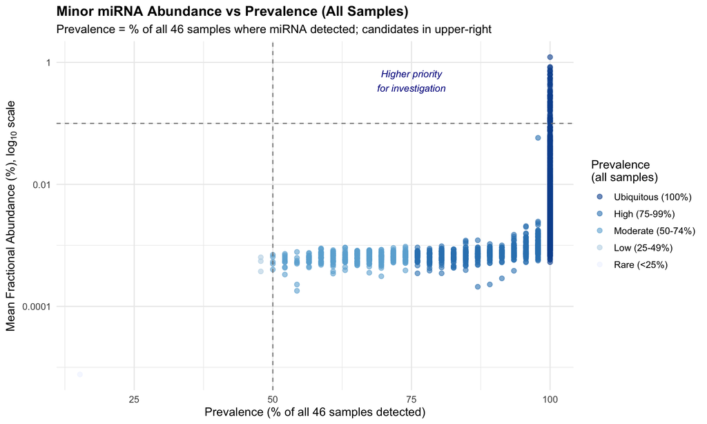

```r
p3 <- ggplot(minor_summary, aes(x = Prevalence * 100, y = Mean_Percentage)) +
  geom_point(aes(color = Prevalence_Category), alpha = 0.6, size = 2) +
  geom_hline(yintercept = 0.1, linetype = "dashed", color = "gray50", size = 0.5) +
  geom_vline(xintercept = 50, linetype = "dashed", color = "gray50", size = 0.5) +
  scale_color_brewer(palette = "Blues", direction = -1, name = "Prevalence\n(all samples)") +
  scale_y_log10(labels = scales::label_number(drop0trailing = TRUE)) +
  labs(
    title = "Minor miRNA Abundance vs Prevalence (All Samples)",
    subtitle = sprintf("Prevalence = %% of all %d samples where miRNA detected; candidates in upper-right",
                      n_samples),
    x = sprintf("Prevalence (%% of all %d samples detected)", n_samples),
    y = expression("Mean Fractional Abundance (%), "*log[10]*" scale")
  ) +
  theme_minimal(base_size = 12) +
  theme(
    plot.title = element_text(face = "bold", size = 14),
    legend.position = "right"
  ) +
  annotate("text", x = 75, y = 0.5, label = "Higher priority\nfor investigation",
           color = "darkblue", fontface = "italic", size = 3.5)

print(p3)
```

```r
save_figure(p3, "minor_miRNA_abundance_vs_prevalence", width = 10, height = 7)
```

```
## Saved: minor_miRNA_abundance_vs_prevalence .png/.pdf
```

## 5.4 Minor miRNAs with ≥0.1% Abundance in CF Samples

```r
# Filter minor miRNAs with ≥0.1% mean abundance in CF samples
abundance_display_threshold <- 0.001  # 0.1%

minor_01pct_cf <- minor_summary %>%
  filter(CF_Mean_Fraction >= abundance_display_threshold) %>%
  arrange(desc(CF_Mean_Fraction)) %>%
  mutate(Rank = row_number())

n_abundant_minor <- nrow(minor_01pct_cf)

cat("Minor miRNAs with ≥0.1% mean abundance in CF samples:", n_abundant_minor, "\n")
```

```
## Minor miRNAs with ≥0.1% mean abundance in CF samples: 72
```

```r
cat("Prevalence distribution (overall):\n")
```

```
## Prevalence distribution (overall):
```

```r
print(table(minor_01pct_cf$Prevalence_Category))
```

```
##
## Ubiquitous (100%)     High (75-99%) Moderate (50-74%)
##                72                 0                 0
##      Low (25-49%)       Rare (<25%)
##                 0                 0
```

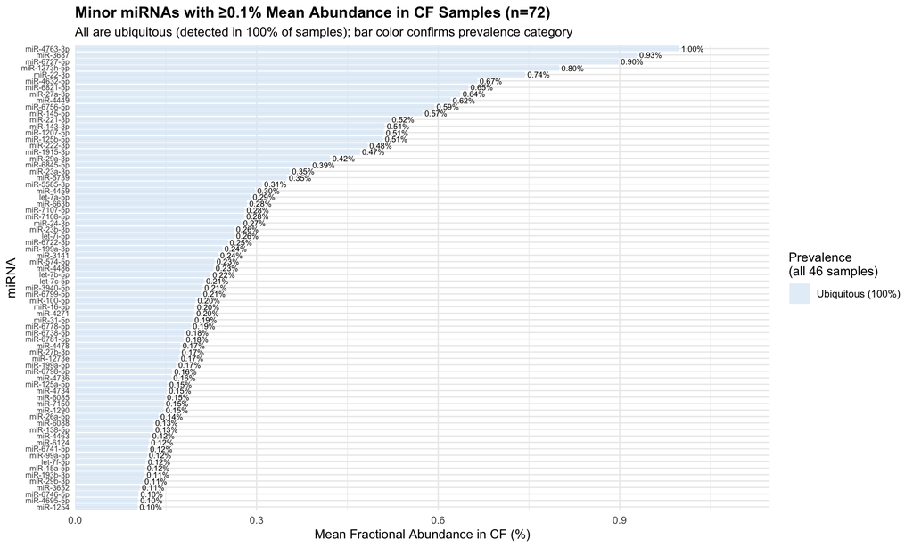

```r
# Calculate figure height based on number of miRNAs
fig_height <- max(8, n_abundant_minor * 0.18)

p4 <- ggplot(minor_01pct_cf, aes(x = reorder(miRNA, -Rank), y = CF_Mean_Percentage)) +
  geom_bar(stat = "identity", aes(fill = Prevalence_Category), alpha = 0.8) +
  geom_text(aes(label = sprintf("%.2f%%", CF_Mean_Percentage)),
            hjust = -0.1, size = 2.2) +
  coord_flip() +
  scale_fill_brewer(palette = "Blues", direction = -1,
                    name = sprintf("Prevalence\n(all %d samples)", n_samples)) +
  labs(
    title = sprintf("Minor miRNAs with ≥0.1%% Mean Abundance in CF Samples (n=%d)", n_abundant_minor),
    subtitle = "All are ubiquitous (detected in 100% of samples); bar color confirms prevalence category",
    x = "miRNA",
    y = "Mean Fractional Abundance in CF (%)"
  ) +
  theme_minimal(base_size = 10) +
  theme(
    plot.title = element_text(face = "bold", size = 12),
    axis.text.y = element_text(size = 6),
    legend.position = "right"
  ) +
  scale_y_continuous(expand = expansion(mult = c(0, 0.15)))

print(p4)
```

```r
save_figure(p4, "minor_miRNAs_01pct_CF", width = 12, height = fig_height)
```

```
## Saved: minor_miRNAs_01pct_CF .png/.pdf
```

```r
# Summary statistics
cat("\n=== Summary for miRNAs ≥0.1% in CF ===\n")
```

```
##
## === Summary for miRNAs ≥0.1% in CF ===
```

```r
cat("Count:", n_abundant_minor, "\n")
```

```
## Count: 72
```

```r
cat("Abundance range:", sprintf("%.2f%% - %.2f%%",
                                 min(minor_01pct_cf$CF_Mean_Percentage),
                                 max(minor_01pct_cf$CF_Mean_Percentage)), "\n")
```

```
## Abundance range: 0.10% - 1.00%
```

```r
cat("Collective contribution (CF mean):",
    sprintf("%.2f%%", sum(minor_01pct_cf$CF_Mean_Percentage)), "\n")
```

```
## Collective contribution (CF mean): 22.05%
```

# 6. Identify Candidate Minor miRNAs for Further Investigation

```r
# Define candidate criteria
abundance_threshold <- 0.001  # 0.1%
prevalence_threshold <- 0.50  # 50% of ALL samples

candidates <- minor_summary %>%
  filter(Mean_Fraction >= abundance_threshold & Prevalence >= prevalence_threshold) %>%
  arrange(desc(Mean_Fraction))

cat("\n=== Candidate Minor miRNAs for Investigation ===\n")
```

```
##
## === Candidate Minor miRNAs for Investigation ===
```

```r
cat("Criteria: Mean abundance ≥", abundance_threshold * 100, "% AND prevalence ≥",
    prevalence_threshold * 100, "% of all", n_samples, "samples\n\n")
```

```
## Criteria: Mean abundance ≥ 0.1 % AND prevalence ≥ 50 % of all 46 samples
```

```r
cat("Number of candidates:", nrow(candidates), "\n\n")
```

```
## Number of candidates: 70
```

```r
if(nrow(candidates) > 0) {
  candidates_display <- candidates %>%
    dplyr::select(miRNA, Mean_Percentage, Prevalence, N_Samples_Detected) %>%
    head(50)
  print(candidates_display)

  if(nrow(candidates) > 50) {
    cat("\n... and", nrow(candidates) - 50, "more candidates\n")
  }

  cat("\nCollective contribution of candidates:",
      sprintf("%.2f%%", sum(candidates$Mean_Percentage)), "\n")
}
```

```
##                     miRNA Mean_Percentage Prevalence
## miR-3687         miR-3687       1.2209890          1
## miR-27a-3p     miR-27a-3p       0.8431855          1
## miR-22-3p       miR-22-3p       0.8156788          1
## miR-125b-5p   miR-125b-5p       0.7480088          1
## miR-222-3p     miR-222-3p       0.7193826          1
## miR-221-3p     miR-221-3p       0.6997217          1
## miR-1273h-5p miR-1273h-5p       0.6452744          1
## miR-6756-5p   miR-6756-5p       0.6268548          1
## miR-29a-3p     miR-29a-3p       0.6233785          1
## miR-145-5p     miR-145-5p       0.5591899          1
## miR-6727-5p   miR-6727-5p       0.5493688          1
## miR-1207-5p   miR-1207-5p       0.5377408          1
## miR-4763-3p   miR-4763-3p       0.5097223          1
## miR-6821-5p   miR-6821-5p       0.4833412          1
## miR-23a-3p     miR-23a-3p       0.4508351          1
## miR-143-3p     miR-143-3p       0.4359077          1
## miR-6845-5p   miR-6845-5p       0.4253475          1
## miR-4632-5p   miR-4632-5p       0.4011132          1
## miR-24-3p       miR-24-3p       0.3600561          1
## miR-6741-5p   miR-6741-5p       0.3420676          1
## miR-1915-3p   miR-1915-3p       0.3366851          1
## miR-23b-3p     miR-23b-3p       0.3258324          1
## miR-199a-3p   miR-199a-3p       0.3160201          1
## miR-4449         miR-4449       0.2927205          1
## let-7a-5p       let-7a-5p       0.2903556          1
## miR-4271         miR-4271       0.2866441          1
## miR-5739         miR-5739       0.2865413          1
## let-7i-5p       let-7i-5p       0.2818167          1
## miR-100-5p     miR-100-5p       0.2813324          1
## miR-4486         miR-4486       0.2728563          1
## miR-5585-3p   miR-5585-3p       0.2639300          1
## miR-31-5p       miR-31-5p       0.2633345          1
## miR-4459         miR-4459       0.2523229          1
## miR-27b-3p     miR-27b-3p       0.2522203          1
## miR-199a-5p   miR-199a-5p       0.2326116          1
## miR-663b         miR-663b       0.2281720          1
## miR-7108-5p   miR-7108-5p       0.2246916          1
## miR-7107-5p   miR-7107-5p       0.2191503          1
## miR-16-5p       miR-16-5p       0.2188171          1
```

[output cut: 51 more lines]

```
## miR-3141                     46
## miR-29b-3p                   46
## miR-6738-5p                  46
## miR-125a-5p                  46
## miR-574-5p                   46
## let-7b-5p                    46
## miR-4478                     46
## let-7c-5p                    46
## miR-6781-5p                  46
## miR-99a-5p                   46
## miR-26a-5p                   46
##
## ... and 20 more candidates
##
## Collective contribution of candidates: 21.64%
```

## 6.1 Visualize Candidates

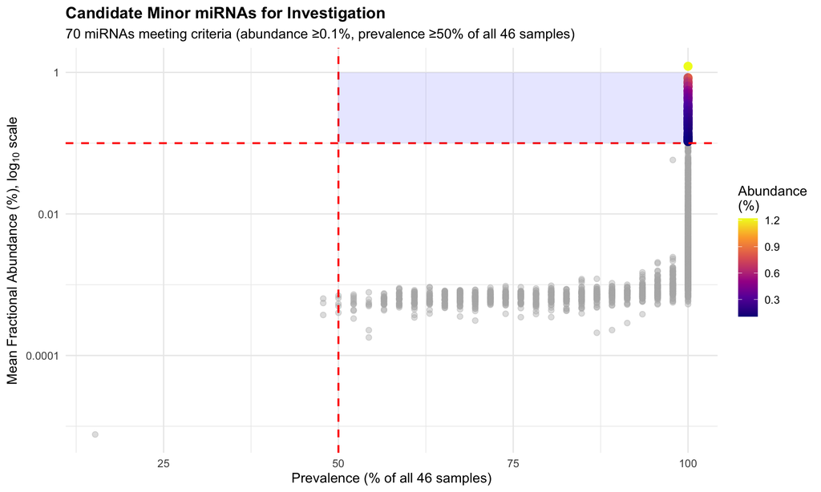

```
## Saved: candidate_minor_miRNAs_highlighted .png/.pdf
```

```r
if(nrow(candidates) > 0) {
  p5 <- ggplot(minor_summary, aes(x = Prevalence * 100, y = Mean_Percentage)) +
    geom_point(color = "gray70", alpha = 0.4, size = 2) +
    geom_point(data = candidates, aes(color = Mean_Percentage), size = 3) +
    geom_hline(yintercept = abundance_threshold * 100, linetype = "dashed",
               color = "red", size = 0.8) +
    geom_vline(xintercept = prevalence_threshold * 100, linetype = "dashed",
               color = "red", size = 0.8) +
    scale_color_viridis_c(option = "plasma", name = "Abundance\n(%)") +
    scale_y_log10(labels = scales::label_number(drop0trailing = TRUE)) +
    labs(
      title = "Candidate Minor miRNAs for Investigation",
      subtitle = sprintf("%d miRNAs meeting criteria (abundance ≥%.1f%%, prevalence ≥%.0f%% of all %d samples)",
                        nrow(candidates), abundance_threshold * 100, prevalence_threshold * 100, n_samples),
      x = sprintf("Prevalence (%% of all %d samples)", n_samples),
      y = expression("Mean Fractional Abundance (%), "*log[10]*" scale")
    ) +
    theme_minimal(base_size = 12) +
    theme(
      plot.title = element_text(face = "bold", size = 14),
      legend.position = "right"
    ) +
    annotate("rect", xmin = prevalence_threshold * 100, xmax = 100,
             ymin = abundance_threshold * 100, ymax = 1,
             alpha = 0.1, fill = "blue")

  print(p5)
  save_figure(p5, "candidate_minor_miRNAs_highlighted", width = 10, height = 7)
}
```

# 7. Prevalence by Treatment Group - Detailed Analysis

```r
# Reshape to wide format for comparison
group_prev_wide <- group_prev_cat_df %>%
  dplyr::select(miRNA, Treatment, Prevalence) %>%
  pivot_wider(names_from = Treatment, values_from = Prevalence, names_prefix = "Prev_")

# Merge with overall summary
minor_summary_extended <- minor_summary %>%
  left_join(group_prev_wide, by = "miRNA")

cat("\n=== Group-Specific Prevalence Summary ===\n")
```

```
##
## === Group-Specific Prevalence Summary ===
```

```r
cat("Prev_CF_Asp_Neg = prevalence within CF samples (n=", group_sample_counts["CF_Asp_Neg"], ")\n", sep = "")
```

```
## Prev_CF_Asp_Neg = prevalence within CF samples (n=16)
```

```r
cat("Prev_HC = prevalence within HC samples (n=", group_sample_counts["HC"], ")\n", sep = "")
```

```
## Prev_HC = prevalence within HC samples (n=14)
```

```r
cat("Prev_UNSTIM = prevalence within UNSTIM samples (n=", group_sample_counts["UNSTIM"], ")\n\n", sep = "")
```

```
## Prev_UNSTIM = prevalence within UNSTIM samples (n=16)
```

```r
cat("(Showing first 20 rows)\n\n")
```

```
## (Showing first 20 rows)
```

```r
print(head(minor_summary_extended %>%
             dplyr::select(miRNA, Mean_Percentage, Prevalence, starts_with("Prev_")), 20))
```

```
##           miRNA Mean_Percentage Prevalence Prev_CF_Asp_Neg Prev_HC
## 1      miR-3687       1.2209890          1               1       1
## 2    miR-27a-3p       0.8431855          1               1       1
## 3     miR-22-3p       0.8156788          1               1       1
## 4   miR-125b-5p       0.7480088          1               1       1
## 5    miR-222-3p       0.7193826          1               1       1
## 6    miR-221-3p       0.6997217          1               1       1
## 7  miR-1273h-5p       0.6452744          1               1       1
## 8   miR-6756-5p       0.6268548          1               1       1
## 9    miR-29a-3p       0.6233785          1               1       1
## 10   miR-145-5p       0.5591899          1               1       1
## 11  miR-6727-5p       0.5493688          1               1       1
## 12  miR-1207-5p       0.5377408          1               1       1
## 13  miR-4763-3p       0.5097223          1               1       1
## 14  miR-6821-5p       0.4833412          1               1       1
```

[output cut: 27 more lines]

## 7.1 Compare Prevalence Across Groups (CF vs HC)

```
##
## === CF vs HC Prevalence Patterns ===
##
## Both Ubiquitous     CF-enriched     HC-enriched         Similar
##            1055              49              11             956
```

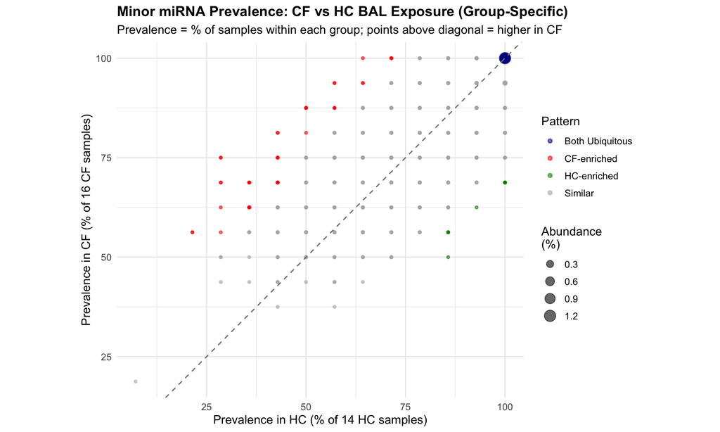

```
## Saved: minor_miRNA_prevalence_CF_vs_HC .png/.pdf
```

```r
if("Prev_CF_Asp_Neg" %in% names(minor_summary_extended) &
   "Prev_HC" %in% names(minor_summary_extended)) {

  n_cf <- group_sample_counts["CF_Asp_Neg"]
  n_hc <- group_sample_counts["HC"]

  minor_summary_extended <- minor_summary_extended %>%
    mutate(
      CF_HC_Prev_Diff = Prev_CF_Asp_Neg - Prev_HC,
      Prev_Pattern = case_when(
        Prev_CF_Asp_Neg == 1 & Prev_HC == 1 ~ "Both Ubiquitous",
        Prev_CF_Asp_Neg > Prev_HC + 0.25 ~ "CF-enriched",
        Prev_HC > Prev_CF_Asp_Neg + 0.25 ~ "HC-enriched",
        TRUE ~ "Similar"
      )
    )

  cat("\n=== CF vs HC Prevalence Patterns ===\n")
  print(table(minor_summary_extended$Prev_Pattern))

  p6 <- ggplot(minor_summary_extended, aes(x = Prev_HC * 100, y = Prev_CF_Asp_Neg * 100)) +
    geom_point(aes(color = Prev_Pattern, size = Mean_Percentage), alpha = 0.6) +
    geom_abline(intercept = 0, slope = 1, linetype = "dashed", color = "gray50") +
    scale_color_manual(values = c("Both Ubiquitous" = "darkblue",
                                   "CF-enriched" = "red",
                                   "HC-enriched" = "green4",
                                   "Similar" = "gray70"),
                       name = "Pattern") +
    scale_size_continuous(name = "Abundance\n(%)", range = c(1, 5)) +
    labs(
      title = "Minor miRNA Prevalence: CF vs HC BAL Exposure (Group-Specific)",
      subtitle = "Prevalence = % of samples within each group; points above diagonal = higher in CF",
      x = sprintf("Prevalence in HC (%% of %d HC samples)", n_hc),
      y = sprintf("Prevalence in CF (%% of %d CF samples)", n_cf)
    ) +
    theme_minimal(base_size = 12) +
    theme(
      plot.title = element_text(face = "bold", size = 14),
      legend.position = "right"
    ) +
    coord_fixed(ratio = 1)

  print(p6)
  save_figure(p6, "minor_miRNA_prevalence_CF_vs_HC", width = 10, height = 8)
}
```

# 8. Differential Expression Analysis: CF vs HC BAL Exposure

## 8.1 Statistical Testing (t-tests)

```r
# Get HC samples
hc_samples <- sample_mapping$Sample[sample_mapping$comparison_7 == "HC"]
hc_samples <- intersect(hc_samples, samples_to_analyze)

n_cf <- length(cf_samples)
n_hc <- length(hc_samples)

cat("Samples for differential expression analysis:\n")
```

```
## Samples for differential expression analysis:
```

```r
cat("  CF BAL samples:", n_cf, "\n")
```

```
##   CF BAL samples: 16
```

```r
cat("  HC BAL samples:", n_hc, "\n")
```

```
##   HC BAL samples: 14
```

```r
# Combine minor ≥0.1% and major miRNAs for testing
mirnas_to_test <- unique(c(minor_01pct_cf$miRNA, major_mirna_names))

cat("Testing", length(mirnas_to_test), "miRNAs (≥0.1% in CF or major)\n\n")
```

```
## Testing 84 miRNAs (≥0.1% in CF or major)
```

```r
# Perform t-tests for each miRNA
ttest_results <- lapply(mirnas_to_test, function(mir) {
  cf_values <- as.numeric(frac_abundance[mir, cf_samples])
  hc_values <- as.numeric(frac_abundance[mir, hc_samples])

  cf_mean <- mean(cf_values)
  hc_mean <- mean(hc_values)

  pseudo <- 1e-8
  log2fc <- log2((cf_mean + pseudo) / (hc_mean + pseudo))

  ttest <- tryCatch({
    t.test(cf_values, hc_values)
  }, error = function(e) {
    list(p.value = NA, statistic = NA)
  })

  if(cf_mean * 100 >= 1) {
    abundance_cat <- "Major (≥1%)"
  } else if(cf_mean * 100 >= 0.1) {
    abundance_cat <- "Minor (0.1-1%)"
  } else {
    abundance_cat <- "Minor (<0.1%)"
  }

  data.frame(
    miRNA = mir,
    CF_Mean_Pct = cf_mean * 100,
    HC_Mean_Pct = hc_mean * 100,
    log2FC = log2fc,
    p_value = ttest$p.value,
    t_statistic = as.numeric(ttest$statistic),
    Abundance_Category = abundance_cat,
    stringsAsFactors = FALSE
  )
})

ttest_df <- do.call(rbind, ttest_results)
ttest_df$neg_log10_p <- -log10(ttest_df$p_value)
ttest_df$Significant <- abs(ttest_df$log2FC) > 1 & ttest_df$p_value < 0.05
ttest_df <- ttest_df %>% arrange(p_value)

cat("=== Differential Expression Summary ===\n")
```

```
## === Differential Expression Summary ===
```

```r
cat("Total tested:", nrow(ttest_df), "\n")
```

```
## Total tested: 84
```

```r
cat("Significant (|log2FC| > 1 & p < 0.05):", sum(ttest_df$Significant, na.rm = TRUE), "\n\n")
```

```
## Significant (|log2FC| > 1 & p < 0.05): 13
```

```r
cat("Top 20 by p-value:\n")
```

```
## Top 20 by p-value:
```

```r
print(head(ttest_df %>% dplyr::select(miRNA, CF_Mean_Pct, HC_Mean_Pct, log2FC, p_value, Abundance_Category), 20))
```

```
##          miRNA CF_Mean_Pct HC_Mean_Pct     log2FC      p_value
## 1  miR-3940-5p   0.2101450  0.07237551  1.5377986 3.899906e-05
## 2  miR-6799-5p   0.2078506  0.09757610  1.0909396 5.115775e-04
## 3     miR-3141   0.2362161  0.14864969  0.6681875 2.599471e-03
## 4   miR-222-3p   0.4828973  1.13006064 -1.2266103 4.944891e-03
## 5  miR-4632-5p   0.6650001  0.29100002  1.1923325 5.003888e-03
## 6     miR-3652   0.1069647  0.02733003  1.9685367 5.649291e-03
## 7  miR-6727-5p   0.8982453  0.48222661  0.8973969 8.078045e-03
## 8     miR-4463   0.1239966  0.08671433  0.5159536 1.012375e-02
## 9     miR-6124   0.1219469  0.06583683  0.8892765 1.164963e-02
## 10 miR-125b-5p   0.5083309  1.24394935 -1.2910862 1.601848e-02
## 11 miR-4763-3p   0.9981190  0.33687075  1.5670139 1.782556e-02
## 12  miR-221-3p   0.5198422  1.12168044 -1.1095147 1.907078e-02
## 13    miR-1254   0.1029232  0.06461121  0.6717039 2.156423e-02
## 14   miR-31-5p   0.1937428  0.43193738 -1.1566756 2.466613e-02
```

[output cut: 27 more lines]

```r
write.csv(ttest_df, file.path(output_dir, "differential_expression_CF_vs_HC.csv"), row.names = FALSE)
```

## 8.2 Volcano Plot

```r
# Load CF-relevant miRNA list for highlighting
cf_annotations_file <- here("data", "metadata", "CF_miRNA_annotations.csv")
cf_relevant_mirnas <- if(file.exists(cf_annotations_file)) {
  read.csv(cf_annotations_file, stringsAsFactors = FALSE)
} else {
  data.frame(miRNA = character(0), Impact = character(0))
}

# Prepare base volcano data from t-test results (miRNAs ≥0.1%)
volcano_data <- ttest_df %>%
  filter(!is.na(p_value) & !is.na(log2FC)) %>%
  mutate(
    Abundance_Category = factor(Abundance_Category,
                                 levels = c("Major (≥1%)", "Minor (0.1-1%)", "Minor (<0.1%)")),
    Is_CF_Relevant = miRNA %in% cf_relevant_mirnas$miRNA
  )

# Add CF-relevant miRNAs that are below 0.1% threshold (not in ttest_df)
# First, calculate stats for CF-relevant miRNAs not in ttest_df
cf_relevant_below_threshold <- cf_relevant_mirnas %>%
  filter(!miRNA %in% ttest_df$miRNA) %>%
  filter(miRNA %in% rownames(frac_abundance))

if(nrow(cf_relevant_below_threshold) > 0) {
  cf_below_stats <- lapply(cf_relevant_below_threshold$miRNA, function(mir) {
    cf_values <- as.numeric(frac_abundance[mir, cf_samples])
    hc_values <- as.numeric(frac_abundance[mir, hc_samples])
    cf_mean <- mean(cf_values, na.rm = TRUE)
    hc_mean <- mean(hc_values, na.rm = TRUE)
    pseudo <- 1e-8
    log2fc <- log2((cf_mean + pseudo) / (hc_mean + pseudo))
    ttest <- tryCatch(t.test(cf_values, hc_values), error = function(e) list(p.value = NA))

    data.frame(
      miRNA = mir,
      CF_Mean_Pct = cf_mean * 100,
      HC_Mean_Pct = hc_mean * 100,
      log2FC = log2fc,
      p_value = ttest$p.value,
      neg_log10_p = -log10(ttest$p.value),
      Abundance_Category = factor("Minor (<0.1%)",
                                   levels = c("Major (≥1%)", "Minor (0.1-1%)", "Minor (<0.1%)")),
      Is_CF_Relevant = TRUE,
      Significant = abs(log2fc) > 1 & ttest$p.value < 0.05,
      stringsAsFactors = FALSE
    )
  })
  cf_relevant_below_threshold <- do.call(rbind, cf_below_stats)
} else {
  cf_relevant_below_threshold <- data.frame()
}

# Combine: all tested miRNAs + CF-relevant below threshold
volcano_data_full <- bind_rows(
  volcano_data,
  cf_relevant_below_threshold
)

cat("Volcano plot includes:\n")
```

```
## Volcano plot includes:
```

```r
cat("  - miRNAs from t-test (≥0.1%):", nrow(volcano_data), "\n")
```

```
##   - miRNAs from t-test (≥0.1%): 84
```

```r
cat("  - CF-relevant below threshold:", nrow(cf_relevant_below_threshold), "\n")
```

```
##   - CF-relevant below threshold: 14
```

```r
cat("  - Total CF-relevant that will be labeled:", sum(volcano_data_full$Is_CF_Relevant), "\n")
```

```
##   - Total CF-relevant that will be labeled: 20
```

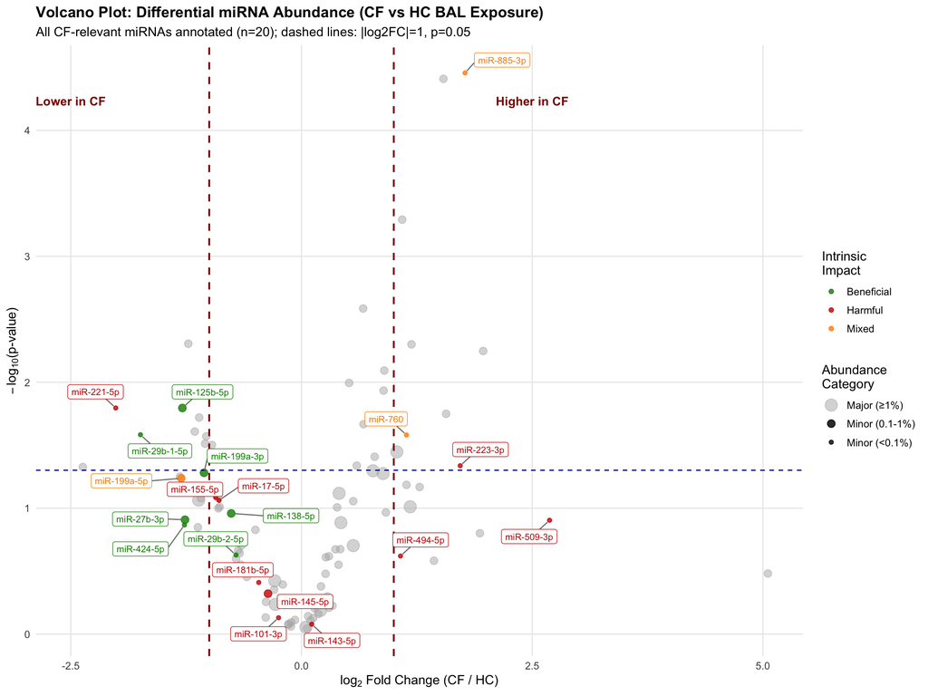

```r
# Get CF-relevant data for annotation
cf_relevant_for_plot <- volcano_data_full %>%
  filter(Is_CF_Relevant) %>%
  left_join(cf_relevant_mirnas %>% dplyr::select(miRNA, Impact), by = "miRNA")

# Create volcano plot
p_volcano <- ggplot(volcano_data_full, aes(x = log2FC, y = neg_log10_p)) +
  # Background points (non-CF-relevant)
  geom_point(data = volcano_data_full %>% filter(!Is_CF_Relevant),
             aes(size = Abundance_Category),
             color = "gray70", alpha = 0.5) +
  # CF-relevant points
  geom_point(data = cf_relevant_for_plot,
             aes(size = Abundance_Category, color = Impact),
             alpha = 0.8) +
  # Vertical lines for |log2FC| > 1
  geom_vline(xintercept = c(-1, 1), linetype = "dashed", color = "darkred", size = 0.8) +
  # Horizontal line for p = 0.05
  geom_hline(yintercept = -log10(0.05), linetype = "dashed", color = "darkblue", size = 0.5) +
  # Labels for CF-relevant miRNAs
  geom_label_repel(data = cf_relevant_for_plot,
                   aes(label = miRNA, color = Impact),
                   size = 3,
                   box.padding = 0.5,
                   point.padding = 0.3,
                   segment.color = "gray50",
                   max.overlaps = 30,
                   show.legend = FALSE) +
  # Scales
  scale_size_manual(values = c("Major (≥1%)" = 5, "Minor (0.1-1%)" = 3, "Minor (<0.1%)" = 1.5),
                    name = "Abundance\nCategory") +
  scale_color_manual(values = c("Beneficial" = "green4",
                                 "Harmful" = "red3",
                                 "Mixed" = "darkorange",
                                 "Unclear" = "purple"),
                     name = "Intrinsic\nImpact") +
  # Labels
  labs(
    title = "Volcano Plot: Differential miRNA Abundance (CF vs HC BAL Exposure)",
    subtitle = sprintf("All CF-relevant miRNAs annotated (n=%d); dashed lines: |log2FC|=1, p=0.05",
                      nrow(cf_relevant_for_plot)),
    x = expression(log[2]*" Fold Change (CF / HC)"),
    y = expression(-log[10]*"(p-value)")
  ) +
  # Theme
  theme_minimal(base_size = 12) +
  theme(
    plot.title = element_text(face = "bold", size = 14),
    legend.position = "right",
    panel.grid.minor = element_blank()
  ) +
  # Annotations for quadrants
  annotate("text", x = -2.5, y = max(volcano_data_full$neg_log10_p, na.rm = TRUE) * 0.95,
         label = "Lower in CF", color = "darkred", fontface = "bold", size = 4) +
  annotate("text", x = 2.5, y = max(volcano_data_full$neg_log10_p, na.rm = TRUE) * 0.95,
         label = "Higher in CF", color = "darkred", fontface = "bold", size = 4)

print(p_volcano)
```

```r
save_figure(p_volcano, "volcano_CF_vs_HC", width = 12, height = 9)
```

```
## Saved: volcano_CF_vs_HC .png/.pdf
```

Key features restored: - Gray background points for non-CF-relevant miRNAs - CF-relevant points colored by **Impact** (Beneficial=green, Harmful=red, Mixed=orange, Unclear=purple) - Point size by **Abundance Category** - `geom_label_repel` labels for **all** CF-relevant miRNAs - CF-relevant miRNAs below 0.1% threshold included - “Lower in CF” / “Higher in CF” quadrant annotations

## 8.3 CF-Relevant miRNAs (if annotation file exists)

```r
# Check for CF-relevant miRNA annotations file
cf_annotations_file <- here("data", "metadata", "CF_miRNA_annotations.csv")

if(file.exists(cf_annotations_file)) {
  cf_relevant_mirnas <- read.csv(cf_annotations_file, stringsAsFactors = FALSE)

  cat("Loaded", nrow(cf_relevant_mirnas), "CF-relevant miRNA annotations\n")
  cat("Impact categories:", paste(unique(cf_relevant_mirnas$Impact), collapse = ", "), "\n\n")

  # Merge with t-test results
  cf_relevant_annotated <- cf_relevant_mirnas %>%
    left_join(ttest_df %>% dplyr::select(miRNA, CF_Mean_Pct, HC_Mean_Pct, log2FC, p_value, Abundance_Category),
              by = "miRNA")

  # For miRNAs not in ttest_df, get their values directly
  for(i in 1:nrow(cf_relevant_annotated)) {
    mir <- cf_relevant_annotated$miRNA[i]
    if(is.na(cf_relevant_annotated$CF_Mean_Pct[i]) && mir %in% rownames(frac_abundance)) {
      cf_values <- as.numeric(frac_abundance[mir, cf_samples])
      hc_values <- as.numeric(frac_abundance[mir, hc_samples])
      cf_mean <- mean(cf_values)
      hc_mean <- mean(hc_values)
      pseudo <- 1e-8

      cf_relevant_annotated$CF_Mean_Pct[i] <- cf_mean * 100
      cf_relevant_annotated$HC_Mean_Pct[i] <- hc_mean * 100
      cf_relevant_annotated$log2FC[i] <- log2((cf_mean + pseudo) / (hc_mean + pseudo))

      ttest <- tryCatch({
        t.test(cf_values, hc_values)
      }, error = function(e) {
        list(p.value = NA)
      })
      cf_relevant_annotated$p_value[i] <- ttest$p.value
    }
  }

  # Add overall mean percentage
  cf_relevant_annotated <- cf_relevant_annotated %>%
    mutate(Mean_Pct = (CF_Mean_Pct + HC_Mean_Pct) / 2)

  # Determine delta effect based on Impact and log2FC direction
  cf_relevant_annotated <- cf_relevant_annotated %>%
    mutate(
      Delta_Effect = case_when(
        p_value >= 0.05 ~ "N.S.",
        Impact == "Beneficial" & log2FC < 0 ~ "Unfavorable",
        Impact == "Beneficial" & log2FC > 0 ~ "Favorable",
        Impact == "Harmful" & log2FC < 0 ~ "Favorable",
        Impact == "Harmful" & log2FC > 0 ~ "Unfavorable",
        Impact == "Mixed" ~ "Context-dependent",
        TRUE ~ "Unclear"
      )
    )

  # Save annotated table
  write.csv(cf_relevant_annotated %>% arrange(desc(Mean_Pct)),
            file.path(output_dir, "CF_relevant_miRNAs_annotated.csv"), row.names = FALSE)

  cat("CF-relevant miRNAs annotated and saved.\n")
  print(cf_relevant_annotated %>%
          dplyr::select(miRNA, Impact, Mean_Pct, log2FC, p_value, Delta_Effect) %>%
          arrange(desc(Mean_Pct)))

  # Create Word document if officer/flextable available
  tryCatch({
    cf_table_for_doc <- cf_relevant_annotated %>%
      arrange(desc(Mean_Pct)) %>%
      dplyr::select(miRNA, Impact, Mean_Pct, log2FC, p_value, Delta_Effect, Key_Mechanism) %>%
      mutate(
        Mean_Pct = sprintf("%.3f%%", Mean_Pct),
        log2FC = sprintf("%.2f", log2FC),
        p_value = ifelse(p_value < 0.001, sprintf("%.2e", p_value), sprintf("%.4f", p_value))
      ) %>%
      rename(
        `Mean %` = Mean_Pct,
        `Δ (log2FC)` = log2FC,
        `p-value` = p_value,
        `CF Effect` = Delta_Effect,
        `Key Mechanisms` = Key_Mechanism
      )

    ft <- flextable(cf_table_for_doc) %>%
      theme_booktabs() %>%
      fontsize(size = 9, part = "all") %>%
      fontsize(size = 10, part = "header") %>%
      bold(part = "header") %>%
      align(align = "center", part = "header") %>%
      align(j = "miRNA", align = "left", part = "body") %>%
      align(j = c("Impact", "Mean %", "Δ (log2FC)", "p-value", "CF Effect"), align = "center", part = "body") %>%
      align(j = "Key Mechanisms", align = "left", part = "body") %>%
      flextable::width(j = "miRNA", width = 1.1) %>%
      flextable::width(j = "Impact", width = 0.7) %>%
      flextable::width(j = "Mean %", width = 0.6) %>%
      flextable::width(j = "Δ (log2FC)", width = 0.6) %>%
      flextable::width(j = "p-value", width = 0.65) %>%
      flextable::width(j = "CF Effect", width = 0.9) %>%
      flextable::width(j = "Key Mechanisms", width = 2.5) %>%
      bg(i = ~ Impact == "Beneficial", j = "Impact", bg = "#CCFFCC") %>%
      bg(i = ~ Impact == "Harmful", j = "Impact", bg = "#FFCCCC") %>%
      bg(i = ~ Impact == "Mixed", j = "Impact", bg = "#FFE5CC") %>%
      bg(i = ~ Impact == "Unclear", j = "Impact", bg = "#E5E5E5") %>%
      bg(i = ~ `CF Effect` == "Favorable", j = "CF Effect", bg = "#CCFFCC") %>%
      bg(i = ~ `CF Effect` == "Unfavorable", j = "CF Effect", bg = "#FFCCCC") %>%
      bg(i = ~ `CF Effect` == "Context-dependent", j = "CF Effect", bg = "#FFE5CC") %>%
      bg(i = ~ `CF Effect` == "Unclear", j = "CF Effect", bg = "#E5E5E5") %>%
      bg(i = ~ `CF Effect` == "N.S.", j = "CF Effect", bg = "#E5E5E5") %>%
      valign(valign = "top", part = "body")

    doc <- read_docx() %>%
      body_add_par("CF-Relevant miRNAs in hMSC EV Cargo", style = "heading 1") %>%
      body_add_par("", style = "Normal") %>%
      body_add_par(sprintf("Analysis of miRNAs with known or suspected relevance to cystic fibrosis pathophysiology. Differential expression comparing CF BAL-exposed (n=%d) vs HC BAL-exposed (n=%d) hMSC extracellular vesicles.", n_cf, n_hc), style = "Normal") %>%
      body_add_par("", style = "Normal") %>%
      body_add_flextable(ft) %>%
      body_add_par("", style = "Normal") %>%
      body_add_par("Table Notes:", style = "heading 2") %>%
      body_add_par("• Impact: Intrinsic effect of miRNA (Beneficial = anti-fibrotic/anti-inflammatory; Harmful = pro-fibrotic or reduces CFTR; Mixed = context-dependent; Unclear = insufficient evidence)", style = "Normal") %>%
      body_add_par("• Mean %: Average fractional abundance across all samples", style = "Normal") %>%
      body_add_par("• Δ (log2FC): Fold change in CF vs HC; positive = higher in CF, negative = higher in HC", style = "Normal") %>%
      body_add_par("• CF Effect: Whether the observed change is favorable given the miRNA's intrinsic impact. N.S. = not significant (p ≥ 0.05)", style = "Normal") %>%
      body_add_par("• p-values from Welch's t-test comparing fractional abundance between groups", style = "Normal")

    print(doc, target = file.path(output_dir, "CF_Relevant_miRNAs_Table.docx"))
    cat("\nWord document created: CF_Relevant_miRNAs_Table.docx\n")
  }, error = function(e) {
    cat("Note: Could not create Word document:", e$message, "\n")
  })

} else {
  cat("Note: CF_miRNA_annotations.csv not found at", cf_annotations_file, "\n")
  cat("Skipping CF-relevant miRNA annotation section.\n")
  cat("To enable this section, create the file with columns: miRNA, Impact, Key_Mechanism\n")
}
```

```
## Loaded 20 CF-relevant miRNA annotations
## Impact categories: Harmful, Beneficial, Mixed
##
## CF-relevant miRNAs annotated and saved.
##           miRNA     Impact     Mean_Pct     log2FC      p_value
## 1   miR-125b-5p Beneficial 0.8761401302 -1.2910862 1.601848e-02
## 2    miR-145-5p    Harmful 0.6560784918 -0.3630349 4.773425e-01
## 3   miR-199a-3p Beneficial 0.3746131950 -1.0564466 5.239979e-02
## 4    miR-27b-3p Beneficial 0.2934611869 -1.2623881 1.235585e-01
## 5   miR-199a-5p      Mixed 0.2894037643 -1.3031291 5.791120e-02
## 6    miR-138-5p Beneficial 0.1737796495 -0.7617093 1.100442e-01
## 7    miR-424-5p Beneficial 0.0622545456 -1.2685284 1.360801e-01
## 8    miR-221-5p    Harmful 0.0241851749 -2.0128879 1.600946e-02
## 9   miR-181b-5p    Harmful 0.0214047158 -0.4630947 3.889752e-01
## 10    miR-17-5p    Harmful 0.0210217739 -0.8936968 8.663633e-02
```

[output cut: 33 more lines]

# 9. Export Data for Further Analysis

```r
# Export full minor miRNA summary
write.csv(minor_summary_extended, file.path(output_dir, "minor_miRNA_summary.csv"), row.names = FALSE)

# Export candidate list
if(nrow(candidates) > 0) {
  write.csv(candidates, file.path(output_dir, "candidate_minor_miRNAs.csv"), row.names = FALSE)
}

# Export minor miRNAs ≥0.1% in CF
write.csv(minor_01pct_cf, file.path(output_dir, "minor_miRNAs_01pct_CF.csv"), row.names = FALSE)

# Export group-specific prevalence data
write.csv(group_prev_cat_df, file.path(output_dir, "minor_miRNA_prevalence_by_group.csv"), row.names = FALSE)

# Export prevalence category summary by treatment
write.csv(category_by_group, file.path(output_dir, "prevalence_categories_by_treatment.csv"), row.names = FALSE)

cat("\n=== Data Files Exported ===\n")
```

```
##
## === Data Files Exported ===
```

```r
cat("1. minor_miRNA_summary.csv - Full summary with prevalence metrics\n")
```

```
## 1. minor_miRNA_summary.csv - Full summary with prevalence metrics
```

```r
cat("2. candidate_minor_miRNAs.csv - Filtered candidates meeting criteria\n")
```

```
## 2. candidate_minor_miRNAs.csv - Filtered candidates meeting criteria
```

```r
cat("3. minor_miRNAs_01pct_CF.csv - Minor miRNAs ≥0.1% in CF samples\n")
```

```
## 3. minor_miRNAs_01pct_CF.csv - Minor miRNAs ≥0.1% in CF samples
```

```r
cat("4. minor_miRNA_prevalence_by_group.csv - Prevalence by treatment group\n")
```

```
## 4. minor_miRNA_prevalence_by_group.csv - Prevalence by treatment group
```

```r
cat("5. prevalence_categories_by_treatment.csv - Category counts by treatment\n")
```

```
## 5. prevalence_categories_by_treatment.csv - Category counts by treatment
```

```r
cat("6. differential_expression_CF_vs_HC.csv - t-test results\n")
```

```
## 6. differential_expression_CF_vs_HC.csv - t-test results
```

```r
cat("\n=== Figures Created ===\n")
```

```
##
## === Figures Created ===
```

```r
cat("1. minor_miRNA_prevalence_histogram.png/.pdf\n")
```

```
## 1. minor_miRNA_prevalence_histogram.png/.pdf
```

```r
cat("2. minor_miRNA_prevalence_categories.png/.pdf\n")
```

```
## 2. minor_miRNA_prevalence_categories.png/.pdf
```

```r
cat("3. minor_miRNA_abundance_vs_prevalence.png/.pdf\n")
```

```
## 3. minor_miRNA_abundance_vs_prevalence.png/.pdf
```

```r
cat("4. minor_miRNAs_01pct_CF.png/.pdf\n")
```

```
## 4. minor_miRNAs_01pct_CF.png/.pdf
```

```r
cat("5. candidate_minor_miRNAs_highlighted.png/.pdf\n")
```

```
## 5. candidate_minor_miRNAs_highlighted.png/.pdf
```

```r
cat("6. minor_miRNA_prevalence_CF_vs_HC.png/.pdf\n")
```

```
## 6. minor_miRNA_prevalence_CF_vs_HC.png/.pdf
```

```r
cat("7. volcano_CF_vs_HC.png/.pdf\n")
```

```
## 7. volcano_CF_vs_HC.png/.pdf
```

```r
cat("\n=== All outputs saved to: ===\n")
```

```
##
## === All outputs saved to: ===
```

```r
cat(output_dir, "\n")
```

```
## /Users/d20605c/Documents/MSC-EV-miRNA-CF-BAL/results/02_minor_miRNA
```

# 10. Summary Statistics

```r
cat("\n")
```

```r
cat("================================================================================\n")
cat("                         MINOR miRNA ANALYSIS SUMMARY                           \n")
```

```
##                          MINOR miRNA ANALYSIS SUMMARY
```

```r
cat("================================================================================\n\n")
cat("PREVALENCE OVERVIEW:\n")
```

```
## PREVALENCE OVERVIEW:
```

```r
cat("--------------------\n")
cat("Total minor miRNAs (<1% mean abundance in CF BAL samples):", nrow(minor_summary), "\n")
```

```
## Total minor miRNAs (<1% mean abundance in CF BAL samples): 2071
```

```r
cat("Collective contribution (overall mean):", sprintf("%.2f%%", sum(minor_summary$Mean_Percentage)), "\n\n")
```

```
## Collective contribution (overall mean): 30.85%
```

```r
cat("By Prevalence Category (overall, across all", n_samples, "samples):\n")
```

```
## By Prevalence Category (overall, across all 46 samples):
```

```r
for(cat_name in levels(minor_summary$Prevalence_Category)) {
  n_cat <- sum(minor_summary$Prevalence_Category == cat_name)
  pct_cat <- n_cat / nrow(minor_summary) * 100
  contrib <- sum(minor_summary$Mean_Percentage[minor_summary$Prevalence_Category == cat_name])
  cat(sprintf("  %s: %d miRNAs (%.1f%%), contributing %.2f%% of reads\n",
              cat_name, n_cat, pct_cat, contrib))
}
```

```
##   Ubiquitous (100%): 1014 miRNAs (49.0%), contributing 30.01% of reads
##   High (75-99%): 659 miRNAs (31.8%), contributing 0.59% of reads
##   Moderate (50-74%): 394 miRNAs (19.0%), contributing 0.25% of reads
##   Low (25-49%): 3 miRNAs (0.1%), contributing 0.00% of reads
##   Rare (<25%): 1 miRNAs (0.0%), contributing 0.00% of reads
```

```r
cat("\nKEY FINDING - ABUNDANT MINOR miRNAs:\n")
```

```
##
## KEY FINDING - ABUNDANT MINOR miRNAs:
```

```r
cat("------------------------------------\n")
cat("Minor miRNAs with ≥0.1% mean abundance in CF:", n_abundant_minor, "\n")
```

```
## Minor miRNAs with ≥0.1% mean abundance in CF: 72
```

```r
cat("Collective contribution in CF:", sprintf("%.2f%%", sum(minor_01pct_cf$CF_Mean_Percentage)), "\n")
```

```
## Collective contribution in CF: 22.05%
```

```r
cat("\nCANDIDATES FOR INVESTIGATION:\n")
```

```
##
## CANDIDATES FOR INVESTIGATION:
```

```r
cat("-----------------------------\n")
cat("Criteria: ≥0.1% overall abundance AND ≥50% overall prevalence\n")
```

```
## Criteria: ≥0.1% overall abundance AND ≥50% overall prevalence
```

```r
cat("Number meeting criteria:", nrow(candidates), "\n")
```

```
## Number meeting criteria: 70
```

```r
if(nrow(candidates) > 0) {
  cat("Collective contribution:", sprintf("%.2f%%", sum(candidates$Mean_Percentage)), "\n")
}
```

```
## Collective contribution: 21.64%
```

```r
cat("\n================================================================================\n")
```